# Data Analysis using Twitter API and Python

```python
# Similarly let's check the last 2 records in the Data Set
DataSet.tail(2)
```

|  | tweetID | tweetText | tweetRetweetCt | tweetFavoriteCt | tweetSource | tweetCreated | userID | userScreen | userName | userCreateDt | userDesc | userFollowerCt | userFriendsCt | userLocation | userTimezone |
| --- | --- | --- | --- | --- | --- | --- | --- | --- | --- | --- | --- | --- | --- | --- | --- |
| 401 | 685580928312315904 | Jennifer Jason Leigh has done some great, dive... | 0 | 1 | TweetDeck | 2016-01-08 21:56:45 | 18453759 | MicahHaley | Micah Haley | 2008-12-29 17:13:31 | Teller of long, drawn-out stories with no punc... | 2154 | 586 | New Orleans | Central Time (US & Canada) |
| 402 | 685570995739062273 | #revenant #Oscars2015 https://t.co/Arcy7RHCAg | 0 | 0 | Twitter Web Client | 2016-01-08 21:17:17 | 2453808479 | themcgeeb | McGee | 2014-04-02 02:03:59 | Runner, drummer, editor. Very big in Sheboygan... | 190 | 395 | S. Philly | Atlantic Time (Canada) |

9.OK, now we have our data in an organized and easy to understand way. Its time to look at it and do some cleaning operations.  
This step is required so that we only use valid values/records in our data and neglect the invalid values/records as they don't have any significance and also so that they don't have any negative impact on our results or analysis  
While going through this data-frame, I saw that there are some values in the column 'userTimezone' which corresponds to 'None'. I have planned to use this column to see the Time Zone, where people were most active on tweeting about the 2015 Oscars. For this, I have to first remove the records with 'None' values in it, as they are not at all useful for me.

```python
# 'None' is treated as null here, so I'll remove all the records having 'None' in their 'userTimezone' column
DataSet = DataSet[DataSet.userTimezone.notnull()]

# Let's also check how many records are we left with now
len(DataSet)
```

```
197
```

```python
# Count the number of tweets in each time zone and get the first 10
tzs = DataSet['userTimezone'].value_counts()[:10]
print tzs
```

```
Pacific Time (US & Canada)    35
Eastern Time (US & Canada)    24
Central Time (US & Canada)    12
Baghdad                        9
Quito                          6
Buenos Aires                   6
Atlantic Time (Canada)         6
Dublin                         5
London                         5
Madrid                         5
dtype: int64
```

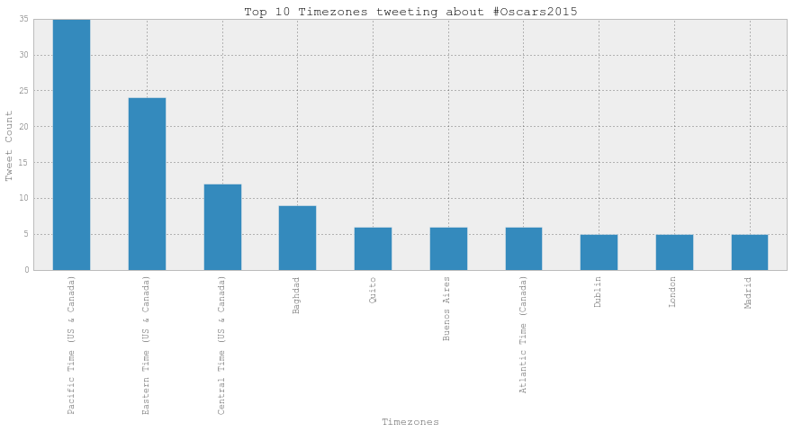

```python
# Create a bar-graph figure of the specified size
plt.rcParams['figure.figsize'] = (15, 5)

# Plot the Time Zone data as a bar-graph
tzs.plot(kind='bar')


# Assign labels and title to the graph to make it more presentable
plt.xlabel('Timezones')
plt.ylabel('Tweet Count')
plt.title('Top 10 Timezones tweeting about #Oscars2015')
```

## Remarks

This was just an attempt on explaining how to use Twitter Search API with python and perform some Data Analysis. I just took "#Oscars2015" as an example, but you can try with something different and more useful.